# “吃老本”还是“吃螃蟹”？——在线课程选择分化与学习效果的比较研究

胡华平

29 六月, 2019

# 1 引言

随着在线课程的迅猛发展，大多数高校已经开始试点在全校范围认定在线课程学分。其中，对于通识类在线课程模块的开设和学分认定，大部分高校率先做出实质性的试点、推广和大规模应用。这主要得益于教育主管部门、高校、市场各方的政策激励和推动，以及通识类课程天然具有受众广、普适性等内在优势。根据师资、经费情况的不同，这些在线通识课程的开设主要通过高校自建或者第三方采购两种方式引入教学使用，而且在线通识课程往往是与传统通识课程并行开课。

把在线课程学习与学分挂钩，学生将面临新的决策条件和学习环境。一方面课程供给形式的自由度增大，学生自主学习的决策性更强，选课和学习热情会更高。另一方面，在线课程大多采用单一机器评价，学生学习过程难以监管，在上课、测试、考核过程中容易出现虚假操作、抄袭、舞弊等现象，课程结业成绩测定容易，但学习效果评估较难。此外，各类在线平台上课程水平参差不齐，还存在学科间课程标准不统一、学习辟垒差异较大等问题(张秀芹 and others 2017)，再加上高校相关配套政策不连续和操作程序尚未完善，容易引发学生的选课困惑和投机行为。

因此，传统课程和在线课程学习条件和学习行为存在较大差异情形下，学生的课程学习效果（如课程考试成绩、课程通过率等）是否可能也会有明显的不同？进一步地，假定学生可以自由选择课程形式，并且都可以获得同等地位的学分认定，课程形式（在线课程或传统课程）选择本身对两类课程的学习效果会带来多大的影响？不考虑课程学习行为（如注册时滞、登陆次数、访问资源次数、视频观看密度和时长、论坛互动数、提交作业数等）时，该如何识别学生背景性因素（包括高考分数、入学年龄、生源地、文理科类别、民族、性别等）对课程形式选择和学习效果产生的额外影响？基于以上考虑，本文将利用学生平台数据库记录数据，分析学生选择两类课程形式的倾向得分，并对学生群体样本进行匹配，从学生背景性因素视角综合对比在线课程选择的分化与学习效果差异。

# 2 文献综述

大量关于在线课程学习效果研究文献主要分析学生在线**学习行为**的影响效应，发现学习者的在线行为对学习效果有着重要影响，在线学习者与学习媒介、同伴和教师多层次广泛交互能提升学习效果(Kizilcec, Piech, and Schneider 2013; 宗阳 et al. 2016; 张晓蕾, 黄振中, and 李曼丽 2017; 王涛涛 and 毛晨蕾 2018)。然而，对于在线课程整体运行和政策环境还不够完善的发展阶段，这些研究一般很难反映学习者的真实学习投入水平，对学习过程中的行为轨迹、意愿与认知过程往往需要结合特定的调研问卷，变量测量准确性和模型预测准确性都会受到一定影响(江波 et al. 2018)。我国大多数本科院校目前正在使用本校或外校建设的在线课程。从使用情况来看，使用外校建设的在线课程数量（56.67%）远远高于本校建设的在线课程（33.33%）。在线课程在教学中的**应用表现**为多种形式，其中主要的应用方式是作为课堂教学的拓展学习资源，以及线上和线下结合的翻转课堂教学(张秀芹 and others 2017)。而且大部分在线课程考核常采用对期末考试、单元测验和参与讨论等学习环节作出加权评价得分，评价体系多元性不足，课程评价主体较为单一，同时机器评介也更容易忽略定性因素的考查(赵宏 et al. 2017)。

实际上影响学生选择在线或传统课程方式及学习效果的因素有很多。学习者选择参与在线课程学习，除了学习者对课程本身的态度、课程内容及质量高低外，学习者的背景特征（性别、地域、家庭条件）、学习动机（终身学习、娱乐或智力激发、职业发展等)、学习能力（自我决策、适应性调节、自主学习等）等均是影响课程方式选择和学习效果的重要方面(姜蔺, 韩锡斌, and 程建钢 2013; 梁林梅 2015)。学生对学习时间的安排能力、人际沟通方式的偏好性等可能会影响其课程决策和学习效果(Roblyer 1999; Hagel and Shaw 2010)。

在实证分析方法上，大量文献基于实验对照的方法分析在线课程和传统课程的学习效果差异，并强调对相关变量的控制和对照(Deschacht and Goeman 2015)。一种理想的对照情形是：一名教师同时开设有传统课程和在线课程，课程学时数近似，且学生能获得的学习资料或内容也差不多相同。Figlio, Rush, and Yin (2013) 对比分析了《微观经济学导论》的学习效果差异，他们发现传统授课形式的学习效果要好于在线授课形式。而 Joyce et al. (2015) 对比分析了传统授课和混合授课形式，发现两种形式下的学习效果仅有微小差异。 Alpert, Couch, and Harmon (2016) 对《经济学原理》不同授课形式做了随机分配，发现在线课程学生的学积分相对要低于传统课程，而且成绩不好的学生的在线课程表现会更糟糕。然而**实验对照分析方法**也具有一定的局限性。控制条件太多容易导致可供分析的学生样本较少，而且随机分配授课方式给特定学生群体还会涉及到社会和伦理问题，研究成本也相对较高。事实上，相比纯粹的**在线授课形式**，**混合在线授课形式**更加普遍。此外，如果在线课程仅仅只是体现在**呈现方式**上的不同，例如只是把传统课程上的课件、练习题、案例等在线化，那么这样的实验对照分析也将缺乏有效性。而且实验对照分析方法更多关注于回答“如果传统课程替换为在线课程，会有什么学习效果差异？”。但是它很难回答“如果学生具有更多在线课程选择，学习效果会有什么差异？”

完全随机的对照控制试验往往很难开展，而且一旦学生选择了在线课程学习，则无法观察到他们如若选择传统课程学习下的学习行为和学习效果。这使得直接采用传统普通多元回归分析方法，很难排除各种复杂混淆因素（如家庭收入、父母受教育程度、居住地、性别等）的对课程学习效果干扰，无法准确识别决定学习效果好坏的真正来源是课程选择本身还是各种复杂混淆因素。基于以上原因，一些学者采用**倾向得分分析（propensity score analysis, PSA）**和**内生转换模型**（endogenous switching model, ESM）来解决上述选择偏误问题，如经典的Heckman两阶段估计方法。Coates et al. (2004) 采用内生转换模型分析发现，在线课程学生分数要显著低于传统课程学生；但是选择在线课程的学生，会优于他们选择传统课程下的表现。通过采用工具变量来矫正选择偏误，Xu and Jaggars (2013) 实证结果发现选择在线课程学习的学生要相对传统课程学习要少获得1/3学分，并更有可能无法最终完成在线课学习，且这种差异在特定样本群组下会更明显，如更年轻的、学积分更低的学生群组。Krieg and Henson (2016) 检验了选择在线课程对于后续课程学分的影响，发现选择在线课程的学生在后续课程（可能是传统课也可能是在线课）学习中成绩相对会有降低。Huntington-Klein, Cowan, and Goldhaber (2017) 采用Heckman两阶段估计发现，一些学生只是因为空间便利性或时间灵活性，而把在线课程作为更乐于接受的新型学习机会（相比于传统课程），但这样往往很难使得这些学生保持连贯性的在线学习并通过课程考核，或者提供更多的在线课程，会使得在同领域课程学习的留存率更低，以及更低的课程通过率。

# 3 理论模型和分析方法

## 3.1 理论模型

高校在校生如果可以在两类课程形式上（在线课程O和传统课程F）自由选择，则可以构建如下的学习效用模型：

$$\begin {align}
u_{i}(c)=\alpha_{i 1} Y_{i c}+\alpha_{i 2} V_{i c}-\alpha_{i 3} P_{i c}
\end {align}$$

其中：

- $u_i(c)$表示学生$i$的效用；
- $Y_{ic}$表示选课的未来折现收益。它依赖于课程学习过程中的人力资本累积；
- $P_{ic}$表示选课的费用；
- $V_{ic}$表示选课的期望消费价值。包括课程学习本身获得的愉悦，以及非经济的或间接成本，比如精神压力。

相对传统课程（face-face），如果学生$i$更偏好在线课程（online），则有：

$$\begin {align}
u_{i}\left(c_{O}\right) & \geq u_{i}\left(c_{F}\right) \Rightarrow \\
\alpha_{i 1} Y_{i O}+\alpha_{i 2} V_{i O}-\alpha_{i 3} P_{i 0} & \geq \alpha_{i 1} Y_{i F}+\alpha_{i 2} V_{i F}-\alpha_{i 3} P_{i F}
&& \leftarrow P_{iO}=P_{iF} \\
\alpha_{i 1}\left(Y_{i O}-Y_{i F}\right)+\alpha_{i 2}\left(V_{i O}-V_{i F}\right) & \geq 0
\end {align}$$

假设在线课程和传统课程学习费用相等，也即$P_{iO}=P_{iF}$。显然，研究的主要关注点在于两个方面：（1）估计$(Y_{i O}-Y_{i F})$，也即在线课程选择会给全体学生带来多少收益？（2）折现收益差$(Y_{i O}-Y_{i F})$与选择行为$u_{i}\left(c_{O}\right) \geq u_{i}\left(c_{F}\right)$的关系。也即选择在线课程的学生，是不是也会在长期上获得最大的折现收益？

事实上，折现收益$(Y_{i O}-Y_{i F})$与期望消费价值$(V_{i O}-V_{i F})$一般呈现负相关关系。如果以上观点成立，这将意味着一个选择在线课程的学生，他的折现收益将会是相对较少的——在线课程太舒适了？这就产生了两个有层次的有趣话题：（1）平均折现收益值（$E(Y_{iO} - Y_{iF}）$是多少？（2）如果选择在线课程，则需要补偿折现收益值，那它是如何不同的？

因此，进一步地可以分别估计不同学习形式的可能性：

$$\begin{align}
\operatorname{Pr} (Y_{i O} =1 ) &=\Phi\left(X_{i O} \beta_{O}\right) \\
\operatorname{Pr} (Y_{i F} =1 ) &=\Phi\left(X_{i F} \beta_{F}\right) \\
\operatorname{Pr} (\text {Online}_{i}=1 ) &=\Phi\left(X_{i} \beta_{S}+Z_{i} \gamma_{S}\right) \\
Online_i & = I(online_i^* \geq 0)
\end{align}$$

其中：$\Phi(\cdot)$为正态分布的累计概率函数cdf；$Y_{iO}$是研究者关心的结果变量（给定在线课程的处置条件），包括后续课程选择，或者是否获得结业学位；$Y_{iF}$是研究者关心的结果变量（给定传统课程的处置条件）：包括后续课程选择，或者是否获得结业学位。$X_{iO};X_{iF}$为变量向量，包括学生背景、早期成就变量、常数项、**随机效应变量**（与学校和课程相关）；$X_i$为变量向量，与$X_{iO};X_{iF}$一样，只是不考虑处置条件（是否为在线课程）；$Z_i$为被斥变量（工具变量）。它能影响选择在线课程还是传统课程，但是不影响结果变量；$Online_i^*$为学生个体在选择在线课程还是传统课程的潜在补偿值。

以上**自我选择问题**（self-selection issue）：Coates et al. (2004)的模型允许学生特征$X_i$对结果变量有不同的影响效应。因而不同课程形式的学校效果在不同群组中是可以不同的。以上模型的参数可以采用倾向得分分析法中的**Heckman两阶段法**估计得到，它仅需要误差项满足**正态分布**条件。

- **第1阶段**：使用probit方法估计如下方程：

$$\begin{align}
\operatorname{Pr} (\text {Online}_{i}=1 ) &=\Phi\left(X_{i} \beta_{S}+Z_{i} \gamma_{S}\right)
\end{align}$$

- **第2阶段**：使用probit方法估计如下方程，并进行矫正：

$$\begin{align}
\operatorname{Pr} (Y_{i O} =1 ) &=\Phi\left(X_{i O} \beta_{O}\right) \\
\operatorname{Pr} (Y_{i F} =1 ) &=\Phi\left(X_{i F} \beta_{F}\right)
\end{align}$$

$$\begin {align}
\operatorname{Pr}\left(Y_{i O}=1\right)
&=\Phi\left(X_{i O} \beta_{O}+\frac{\phi\left(X_{i} \widehat{\beta_{S}}+Z_{i} \widehat{\gamma_{S}}\right)}{\Phi\left(X_{i} \widehat{\beta_{S}}+Z_{i} \widehat{\gamma_{S}}\right)} \delta_{O}\right) \\
\operatorname{Pr}\left(Y_{i F} =1\right)
&=\Phi\left(X_{i F} \beta_{F}+\frac{-\phi\left(X_{i} \widehat{\beta_{S}}+Z_{i} \widehat{\gamma_{S}}\right)}{1-\Phi\left(X_{i} \widehat{\beta_{S}}+Z_{i} \widehat{\gamma}_{S}\right)} \delta_{F}\right)
\end {align}$$

其中，$\phi(\cdot)$表示正态分布的概率密度函数pdf

## 3.2 倾向得分分析（PSA）和处置效应（TE）

**倾向得分分析（propensity score analysis, PSA）**方法最早由Rosenbaum(Rosenbaum and others 1987; Rosenbaum 2010) 提出，作为效果评估的常用工具，很早就被应用于在线学习效果研究领域(Guo and Fraser 2014; 顾振华 and others 2018)。研究者能把观察性样本数据（如学生在线课程选择和学习数据），处理成随机实验等效的样本数据（考虑到学生潜在可能选择传统课程并获得可能的课程成绩），从而减弱了样本自选择引起的模型内生性问题。

1. 倾向得分匹配。主要采用logit模型获得倾向得分（propensity score），依概率匹配选择在线课程的学生样本和选择传统课程的学生样本，并考虑多个协变量（如高考分数、性别、生源地等）下对样本进行匹配平衡。
2. 利用匹配样本进行多元回归分析。匹配平衡后的样本数据，已经把课程形式（在线课程或传统课程）选择对学习效果的影响，效应利用进行多元回归分析。
3. 利用多元回归分析结果，计算两类处置效应：平均处置效应（ATE）和处置后的平均处置效应（ATT）。

处置效应（treatment effect）一般指测试组（选择在线课程）平均得分与控制组（选择传统课程）平均得分的净差值。主要分为平均处置效应(average treatment effect, ATE)和平均处置的处置效应(The average treatment effect on the treated, ATT)。如果采用随机化的处置分派机制（random treatment assignment mechanism,RTAM），那么以上两个效应应该是等价的，也即$ATE=ATT$。大量文献表明在实践应用研究中，二者往往是不相等的。

**平均处置效应**（ATE），有时候也称为平均因果效应(average causal effect, ACE)，是指处置组和控制组在结果变量的平均差异。理论上可以表达为：

$$\begin{align}
ATE =\tau &=E(Y_{i1}|W=1)-E(Y_{i0}|W=0) \\
& = E \left[ (Y_{i1}|W=1) - (Y_{i0}|W=0) \right] && \leftarrow \text{(give assumptions)}
\end{align}$$

本研究中**平均处置效应**ATE，可以理解为“对选择做出矫正后的平均效应”，它能回答这样的问题：在线课程选择可能性存在的条件下，**全体学生**平均收益水平是多少？可以进一步可以表达为：

$$\begin{align}
ATE = \frac{1}{N_{O}+N_{F}} \sum_{N_{o}+N_{F}}\left[\operatorname{Pr}\left(Y_{i O}=1 | X_{i} \hat{\beta}_{O}\right)-\operatorname{Pr}\left(Y_{i F}=1 | X_{i} \hat{\beta}_{F}\right)\right]
\end {align}$$

其中，$N_O;N_F$分别表示在线课程选择和传统课程选择的数量。

**平均处置的处置效应**（ATT），有时候也称为处置后的处置效应 (treatment effect on the treated, TOT)，是指实际处置条件下处置组和控制组在结果变量的平均差异。理论上可以表达为：

$$\begin{align}
ATT &=E \left[ (Y_{i1}-Y_{i0})|X,W=1 \right]
\end{align}$$

实践应用中研究者更为关心的问题是：实际选择在线课程的学生群体平均收益水平是多少？而计算**处置后的平均处置效应**正好能回答该问题。本研究中ATT可以理解为：实际选择在线课程的学生群体，平均提高课程成绩分值或平均降低课程成绩的分值。进一步表达为：

$$\begin {align}
A T T=\frac{1}{N_{O}} \sum_{\mathrm{N}_{\mathrm{O}}}\left[\operatorname{Pr}\left(Y_{i O}=1 | X_{i O} \hat{\beta}_{O}\right)-\operatorname{Pr}\left(Y_{i F}=1 | X_{i O} \hat{\beta}_{F}\right)\right]
\end {align}$$

# 4 实证结果

## 4.1 描述性分析

样本分布情况：

表4.1: 定量变量的描述性统计n= 5265

| 变量 | 定义 | 均值 | 标准差 |
| --- | --- | --- | --- |
| age_enroll | 入学年龄 | 18.614 | 0.966 |
| n_course | 选修课程数 | 4.243 | 4.675 |
| score | 课程成绩 | 72.827 | 13.740 |
| score_diff | 高考分数与录取线分数差值 | 35.027 | 32.938 |

表4.2: 定性变量的描述性统计n= 5265

| 变量 | 取值 | 定义 | 样本数 | 百分比 |
| --- | --- | --- | --- | --- |
| treat | 0 | 选择传统课程 | 2741 | 52.1% |
| treat | 1 | 选择在线课程 | 2524 | 47.9% |
| province | east | 东部地区 | 1338 | 25.4% |
| province | west | 西部地区 | 2793 | 53.0% |
| province | mid | 中部地区 | 1134 | 21.5% |
| diploma | grad | 正常毕业 | 5126 | 97.4% |
| diploma | fail | 肄业或不能毕业 | 139 | 2.6% |
| role | sci | 理科生 | 4927 | 93.6% |
| role | art | 文科生 | 338 | 6.4% |
| nation | han | 汉族 | 4814 | 91.4% |
| nation | min | 少数民族 | 451 | 8.6% |
| politic | CPM | 共产党员 | 831 | 15.8% |
| politic | CLM | 共青团员 | 4306 | 81.8% |
| politic | MAS | 群众 | 128 | 2.4% |
| habitat | urban | 城镇 | 2891 | 54.9% |
| habitat | rural | 农村 | 2374 | 45.1% |
| batch | pre | 往届 | 939 | 17.8% |
| batch | cur | 应届 | 4326 | 82.2% |
| gender | male | 男性 | 2710 | 51.5% |
| gender | female | 女性 | 2555 | 48.5% |

对于因变量而言，在**课程方式**（在线课程、传统课程）分组情形下，均值差异的t检验表明课程成绩score（以及标准化成绩score_std）是存在显著分组差异的。

本研究重点关注如下协变量：n_course（选课数量）、score_diff_std（标准化的高考分数与录取线的分值差）、age_enroll_std（标准化的入学年龄）、province_west（是否西部地区）、diploma_grad（是否正常毕业）、role_sci（是否理科生）、nation_han（是否汉族）、politic_CLM（是否共青团员）、gender_female（是否女性）。在**课程方式**（在线课程、传统课程）分组情形下，均值差异的t检验表明除了age_enroll、habitat_rural 、batch_cur，其他协变量下都表现出显著的分组均值差异。

表4.3: 分组情形下协变量均值差异的t检验

| variables | treat_0 | treat_1 | t | p | mark |
| --- | --- | --- | --- | --- | --- |
| score | 72.1573(10.5915) | 73.5541(16.4640) | -3.6269 | 0.0003 | *** |
| score_diff | 36.2248(31.2840) | 33.7268(34.6037) | 2.7395 | 0.0062 | *** |
| age_enroll | 18.6191(0.9971) | 18.6078(0.9312) | 0.4271 | 0.6693 |  |
| province_east | 0.2415(0.4281) | 0.2678(0.4429) | -2.1882 | 0.0287 | ** |
| role_sci | 0.9471(0.2239) | 0.9235(0.2658) | 3.4642 | 0.0005 | *** |
| nation_han | 0.9066(0.2910) | 0.9227(0.2671) | -2.0982 | 0.0359 | ** |
| politic_CPM | 0.1769(0.3817) | 0.1371(0.3440) | 3.9851 | 0.0001 | *** |
| habitat_rural | 0.4608(0.4986) | 0.4402(0.4965) | 1.5015 | 0.1333 |  |
| batch_cur | 0.8198(0.3844) | 0.8237(0.3812) | -0.3711 | 0.7105 |  |
| gender_female | 0.5830(0.4932) | 0.3792(0.4853) | 15.1084 | 0.0000 | *** |

尽管如此，一些学者认为传统群组均值t检验不应用于匹配平衡分析(Imai, King, and Stuart 2008; King et al. 2011, pg:7)。

## 4.2 估计倾向得分:logit模型

采用logit模型估计倾向得分，结果如下：

表4.4: 倾向得分的logit模型估计结果

vars

coef

std

z

p

mark

(Intercept)

1.4343

0.7038

2.0378

0.0416

score_diff

-0.0029

0.0009

-3.1779

0.0015

***

age_enroll

-0.0401

0.0343

-1.1696

0.2422

province_east

0.1111

0.0664

1.6731

0.0943

role_sci

-0.5627

0.1183

-4.7556

0.0000

***

nation_han

0.3096

0.1074

2.8822

0.0039

***

politic_CPM

-0.1906

0.0798

-2.3883

0.0169

habitat_rural

-0.0979

0.0591

-1.6568

0.0976

batch_cur

0.0484

0.0844

0.5734

0.5663

gender_female

-0.8719

0.0582

-14.9700

0.0000

***

同时计算出以上logit模型的两个拟合优度指标：麦克法登伪$R^2$值为0.0384；模型预测正确率为60.6%。最终估计的样本回归函数如下：

$$\begin{equation}
\begin{alignedat}{999}
&\widehat{logit(treat)}=&&+1.4343&&-0.0029score_{diff}&&-0.0401age_{enroll}&&+0.1111province_{east}\\
&\text{(z)}&&(2.0378)&&(-3.1779)&&(-1.1696)&&(1.6731)\\
&\text{(se)}&&(0.7038)&&(0.0009)&&(0.0343)&&(0.0664)\\
&\text{(cont.)}&&-0.5627role_{sci}&&+0.3096nation_{han}&&-0.1906politic_{CPM}&&-0.0979habitat_{rural}\\
&\text{(z)}&&(-4.7556)&&(2.8822)&&(-2.3883)&&(-1.6568)\\
&\text{(se)}&&(0.1183)&&(0.1074)&&(0.0798)&&(0.0591)\\
&\text{(cont.)}&&+0.0484batch_{cur}&&-0.8719gender_{female}\\
&\text{(z)}&&(0.5734)&&(-14.9700)\\
&\text{(se)}&&(0.0844)&&(0.0582)\\
&\text{(fitness)}&& n=5265;&& R^2=0.0384;&& \text{accracy}=60.59\%\\
\end{alignedat}
\end{equation}$$

绘制倾向得分直方图

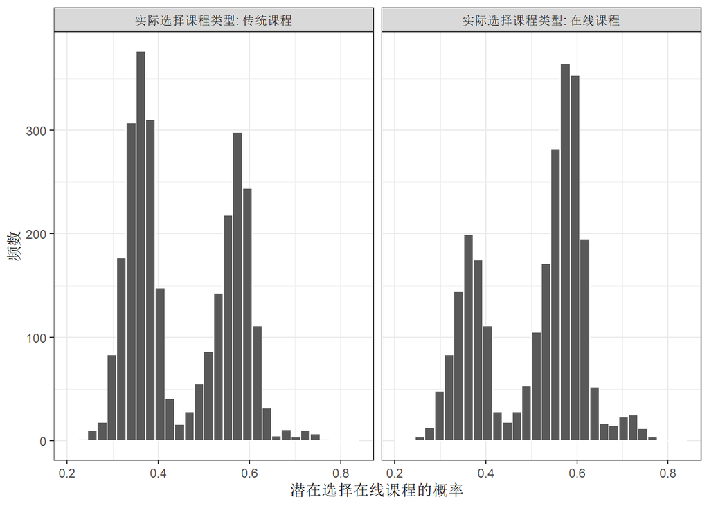

图4.1: 潜在选择在线课程的概率分布对比

## 4.3 样本匹配

采用R包`MatchIt`中的一种全局性匹配算法**optimal**进行1：1的样本匹配(King et al. 2011; Guo and Fraser 2014, pg:190–194)。该最优化匹配算法（optimal）能够根据全部样本的倾向得分，利用全局性的距离最近匹配规则，尽量保留实验组样本（本研究中为选择在线课程的学生），并把处置条件不同（选择在线课程，或者选择传统课程）、但倾向得分相近的样本做1：1的配对。算法匹配的最终结果为：匹配样本总数为5048（因为是1：1配对，也即选择在线课程和选择传统课程的样本数各为2524）；未匹配而丢弃的样本数为217。

表4.5: 倾向得分匹配后样本在协变量平衡上的改善情况

| variables | 均值差改善百分比% | QQ图均值差改善百分比% |
| --- | --- | --- |
| distance | 22% | 22% |
| score_diff | 8% | 4% |
| age_enroll | -148% | -28% |
| province_east | 38% | 39% |
| role_sci | 19% | 19% |
| nation_han | 68% | 68% |
| politic_CPM | 68% | 68% |
| habitat_rural | 83% | 83% |
| batch_cur | -82% | -80% |
| gender_female | 18% | 18% |

## 4.4 学习成绩的回归分析

采用多元虚拟变量回归模型估计结果如下：

表4.6: 学习效果的多元回归模型估计结果

vars

coef

std

t

p

mark

(Intercept)

75.8452

4.8817

15.5366

0.0000

***

treat

1.9864

0.3942

5.0390

0.0000

***

score_diff

0.0286

0.0061

4.6553

0.0000

***

age_enroll

-0.3128

0.2378

-1.3150

0.1886

province_east

0.8497

0.4513

1.8828

0.0598

role_sci

-2.0713

0.7922

-2.6147

0.0090

***

nation_han

0.3850

0.7505

0.5131

0.6079

politic_CPM

2.2540

0.5611

4.0171

0.0001

***

habitat_rural

1.6479

0.4036

4.0832

0.0000

***

batch_cur

-0.0412

0.5830

-0.0707

0.9437

gender_female

2.3954

0.4047

5.9188

0.0000

***

最终估计的样本回归函数如下：

$$\begin{equation} \begin{alignedat}{999} &\widehat{score}=&&+75.85&&+1.99treat&&+0.03score_{diff}&&-0.31age_{enroll}\\ &\text{(t)}&&(15.5366)&&(5.0390)&&(4.6553)&&(-1.3150)\\&\text{(se)}&&(4.8817)&&(0.3942)&&(0.0061)&&(0.2378)\\&\text{(cont.)}&&+0.85province_{east}&&-2.07role_{sci}&&+0.39nation_{han}&&+2.25politic_{CPM}\\&\text{(t)}&&(1.8828)&&(-2.6147)&&(0.5131)&&(4.0171)\\&\text{(se)}&&(0.4513)&&(0.7922)&&(0.7505)&&(0.5611)\\&\text{(cont.)}&&+1.65habitat_{rural}&&-0.04batch_{cur}&&+2.40gender_{female}\\&\text{(t)}&&(4.0832)&&(-0.0707)&&(5.9188)\\&\text{(se)}&&(0.4036)&&(0.5830)&&(0.4047)\\&\text{(fitness)}&& R^2=0.0246;&& \bar{R^2}=0.0226\\& && F^{\ast}=12.68;&& p=0.0000\\ \end{alignedat} \end{equation}$$

## 4.5 计算处置效应

利用以上回归结果，且给定**基准群组**为：选择传统课程、入学年龄为19岁、入学录取分差为36分、生源地为东部省份、理科生、汉族、共产党员、户籍为农村、应届、女生（也即：treat=0;age_enroll=19;score_diff=36;province_east=1;role_sci=1;nation_han=1;politic_CPM=1;habitat_rural=1;batch_cur=1;gender_female=1）。我们可以分析得到几类典型群体的学习成绩差异（见表4.7）。

表4.7: 几类典型群体的学习成绩（与基准组对比）

| group | comp_label | mean_ev0 | mean_ev1 | diff |
| --- | --- | --- | --- | --- |
| 男性群体 | treat=1;gender_female=0 | 76.34 | 75.93 | -0.4100 |
| 高考分差低的群体 | treat=1;score_diff=5 | 76.38 | 77.46 | 1.0889 |
| 城镇群体 | treat=1;habitat_rural=0 | 76.30 | 76.66 | 0.3615 |
| 非东部生源群体 | treat=1;province_east=0 | 76.34 | 77.51 | 1.1673 |

**平均处置效应**（ATE）是“对课程选择行为做出**矫正后**的平均效应”。简言之，它能回答：**在线课程选择**存在的条件下，**全体学生**平均收益水平是多少？根据模型估计和预测结果（见表4.8），**平均处置效应**（ATE）为-0.7697，表明如果学生能够自由选择在线课程，那么全体学生的课程成绩能够平均降低了-0.7697分。

而**处置后的平均处置效应**（ATT）是“学生实际选择**在线课程**的平均平均效应”。 简言之，它能回答：实际选择在线课程的学生群体平均收益水平是多少？根据模型估计和预测结果（见表4.8），**处置后的平均处置效应**（ATT）为0.0875，表明如果学生实际选择在线课程，那么这些选择在线课程的学生，其课程成绩能够平均提高0.0875分。

表4.8: 处置效应ATE和ATT计算表

| type | mean1 | mean0 | TE | sd | 2.5% | 97.5% |
| --- | --- | --- | --- | --- | --- | --- |
| ATE | 72.02 | 73.56 | -0.7697 | 0.817 | 71.70 | 74.10 |
| ATT | 72.02 | 71.84 | 0.0875 | 7.446 | 54.79 | 89.54 |

> ATE和ATT根据模型估计结果并采用bootstrap迭代法进行1000次模拟计算得到。

Alpert, William T, Kenneth A Couch, and Oskar R Harmon. 2016. “A Randomized Assessment of Online Learning.” *American Economic Review* 106 (5): 378–82.

Coates, Dennis, Brad R Humphreys, John Kane, and Michelle A Vachris. 2004. “‘No Significant Distance’ Between Face-to-Face and Online Instruction: Evidence from Principles of Economics.” *Economics of Education Review* 23 (5): 533–46.

Deschacht, Nick, and Katie Goeman. 2015. “The Effect of Blended Learning on Course Persistence and Performance of Adult Learners: A Difference-in-Differences Analysis.” *Computers & Education* 87: 83–89.

Figlio, David, Mark Rush, and Lu Yin. 2013. “Is It Live or Is It Internet? Experimental Estimates of the Effects of Online Instruction on Student Learning.” *Journal of Labor Economics* 31 (4): 763–84.

Guo, Shenyang, and Mark W Fraser. 2014. *Propensity Score Analysis*. Sage.

Hagel, Pauline, and Robin N Shaw. 2010. “How Important Is Study Mode in Student University Choice?” *Higher Education Quarterly* 64 (2): 161–82.

Huntington-Klein, Nick, James Cowan, and Dan Goldhaber. 2017. “Selection into Online Community College Courses and Their Effects on Persistence.” *Research in Higher Education* 58 (3): 244–69.

Imai, Kosuke, Gary King, and Elizabeth Stuart. 2008. “Misunderstandings Among Experimentalists and Observationalists About Causal Inference.” *Journal of the Royal Statistical Society, Series A* 171, part 2: 481502.

Joyce, Ted, Sean Crockett, David A Jaeger, Onur Altindag, and Stephen D O’Connell. 2015. “Does Classroom Time Matter?” *Economics of Education Review* 46: 64–77.

King, Gary, Daniel Ho, Elizabeth A Stuart, and Kosuke Imai. 2011. “MatchIt: Nonparametric Preprocessing for Parametric Causal Inference.” *Journal of Statistical Software* 42 (8): 1–28.

Kizilcec, René F, Chris Piech, and Emily Schneider. 2013. “Deconstructing Disengagement: Analyzing Learner Subpopulations in Massive Open Online Courses.” In *Proceedings of the Third International Conference on Learning Analytics and Knowledge*, 170–79. ACM.

Krieg, John M, and Steven E Henson. 2016. “The Educational Impact of Online Learning: How Do University Students Perform in Subsequent Courses?” *Education Finance and Policy* 11 (4): 426–48.

Roblyer, Mi D. 1999. “Is Choice Important in Distance Learning? A Study of Student Motives for Taking Internet-Based Courses at the High School and Community College Levels.” *Journal of Research on Computing in Education* 32 (1): 157–71.

Rosenbaum, Paul R. 2010. *Design of Observational Studies*. Vol. 10. Springer.

Rosenbaum, Paul R, and others. 1987. “The Role of a Second Control Group in an Observational Study.” *Statistical Science* 2 (3): 292–306.

Xu, Di, and Shanna Smith Jaggars. 2013. “The Impact of Online Learning on Students’ Course Outcomes: Evidence from a Large Community and Technical College System.” *Economics of Education Review* 37: 46–57.

姜蔺, 韩锡斌, and 程建钢. 2013. “MOOCs 学习者特征及学习效果分析研究.” *中国电化教育* 11: 54–59.

宗阳, 孙洪涛, 张亨国, 郑勤华, and 陈丽. 2016. “MOOCs 学习行为与学习效果的逻辑回归分析.” *中国远程教育*, no. 5: 14–22.

张晓蕾, 黄振中, and 李曼丽. 2017. “在线学习者 ‘交互学习’ 体验及其对学习效果影响的实证研究.” *清华大学教育研究*, no. 2: 117–24.

张秀芹, and others. 2017. “在线课程学分认定现状, 问题与对策——基于 61 所高校的调研报告.” *中国大学教学*, no. 2017 年 01: 79–83.

梁林梅. 2015. “MOOCs 学习者: 分类, 特征与坚持性.” *比较教育研究* 1: 28–34.

江波, 高明, 陈志翰, and 王小霞. 2018. “基于行为序列的学习过程分析与学习效果预测.” *现代远程教育研究*, no. 2: 103–12.

王涛涛, and 毛晨蕾. 2018. “基于学习分析的在线课程学习效果评价研究.” *中国成人教育*, no. 17: 27.

赵宏, 张亨国, 郑勤华, and 陈丽. 2017. “中国 Moocs 学习评价调查研究.” *中国电化教育* 9: 53–61.

顾振华, and others. 2018. “混合型考核机制对大学生成绩的影响——基于经济学课程的实证分析.” *高等财经教育研究*, no. 2018 年 01: 11–16.